# 2.6 — Long Run Industry Equilibrium — (Elasticity Question Solutions)

ECON 306

The supply of bicycle rentals in a small town is given by:

$$q_S=10p-200$$

### 1. Find the inverse supply function.

We need to solve this equation for $p$:

$$\begin{align*}
q_s &= 10p - 200 && \text{Original supply equation}\\
q_s + 200 &= 10p && \text{Adding 200 to both sides}\\
\frac{1}{10}q_s + 20 &= p && \text{Dividing both sides by
10}\\
\end{align*}$$

### 2. What is the price elasticity of supply at a price of $25?

The formula for price elasticity of supply is $\epsilon = \frac{1}{slope} * \frac{p}{q}$. We know the slope and $p$, so we first have to find the quantity supplied, $q$ at $25.

We can find this by plugging in $p=25$ into the original supply function:

$$\begin{align*}
q_s & = 10p-200 \\
q_s & = 10(25) - 200 \\
q_s & = 250 - 200\\
q_s &= 50\\
\\ \end{align*}$$

Now we can take everything and plug it into the elasticity formula:

$$\begin{align*}
\epsilon & = \frac{1}{slope} * \frac{p}{q} \\
\epsilon & = \cfrac{1}{\left(\frac{1}{10}\right)} *
\frac{(25)}{(50)} \\
\epsilon & = 10 * 0.5 \\
\epsilon & = 5\\
\\ \end{align*}$$

This is relatively *elastic*: for every 1% increase (decrease) in price, quantity supplied will increase (decrease) by 5%.

### 3. What is the price elasticity of supply at a price of $50?

The formula for price elasticity of supply is $\epsilon = \frac{1}{slope} * \frac{p}{q}$. We know the slope and $p$, so we first have to find the quantity supplied, $q$ at $50.

$$\begin{align*}
q_s & = 10p-200 \\
q_s & = 10(50) - 200 \\
q_s & = 500 - 200\\
q_s &= 300\\
\\ \end{align*}$$

Now we can take everything and plug it into the elasticity formula:

$$\begin{align*}
\epsilon & = \frac{1}{slope} * \frac{p}{q} \\
\epsilon & = \cfrac{1}{\left(\frac{1}{10}\right)} *
\frac{(50)}{(300)} \\
\epsilon & = 10 * \frac{1}{6} \\
\epsilon & = \frac{10}{6} \approx 1.67\\
\\ \end{align*}$$

This is *also* relatively *elastic* (but less elastic than at $25): for every 1% increase (decrease) in price, quantity supplied will increase (decrease) by 1.67%.

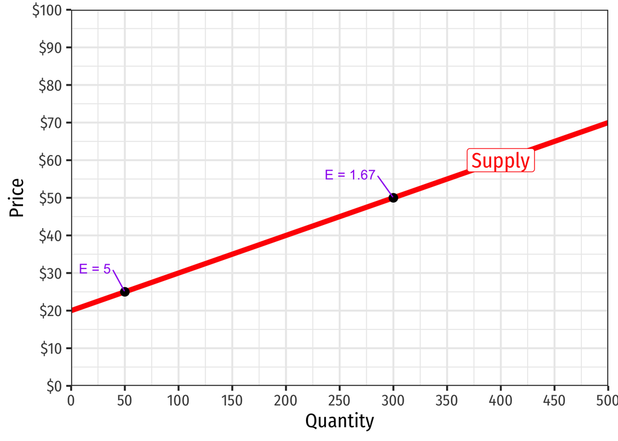